# Fleet data cleaning and analysis

Yanlin Qi

2/2/2021

## Data transformation

To clean the data, several steps have been completed as follows,

1.Replaced all cells that contain “Null” and “No Data” to NA.

2.Removed duplicate vehicles by filtering distinct **Equipment_Number**.

3.Converted **Model_Year, Report_Year, Payload_Rating,Shipping_Weight,Disposition_Mileage,Disposition_Sold_Amount, Total_Miles** from the character type to the numeric type.

4.Converted phrases in **Agency** into a normal sequence and simplified the contents by replacing “Department of” into “Dept. of”; for example, “Forestry and Fire Protection, Department of” was converted into “Dept. of Forestry and Fire Protection”.

5.Extracted numbers from **Purchase_Price** to make this column to be numeric, and renamed it into Purchase_Price_in_Dollar.

6.Re-encoded the columns of **Disposed** and **Passenger_Vehicle** from “Yes” and “No” into logical variables “TRUE” and “FALSE”, which can be directly identified by R.

7.Split the **Acquisition_Delivery_Date** and **Disposition_Date** into **Acquisition_Month, Acquisition_Day, Acquisition_Year** and **Disposition_Month, Disposition_Day, Disposition_Year**. The generated columns have also converted into numeric variables for further calculation.

8.The encoding types of the **Acquisition_Delivery_Date** column is not consistent, which contains both “%m/%d%Y” and *short date* (the bottom half) types . To correctly separate the date data, identification of dates represented in *short-date* type and additional converting processing have been done to avoid error conversions for this column.

The processed data can be checked at ./Data/fleet_data_processed.csv

## Part 2

The visualization of the top 10 agencies that have the largest fleet size in 2018 is shown as follows.

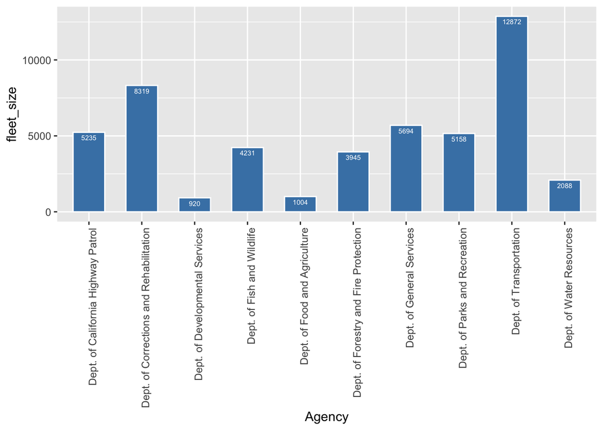

## Part 3

Vehicle acquisition distributions over different months are shown as follows. It shows that vehicle acquisition distributions are not uniformly distributed. Vehicle acquisition in Jan was much larger than other months while Feb owned the least vehicle acquisition.

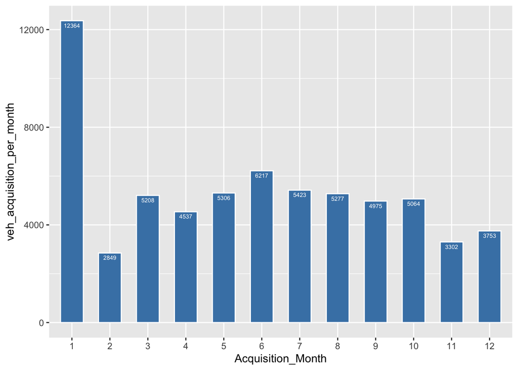

## Part 4

The most popular make of vehicles in state fleets is calculated and printed by the program output as follows.

```
## CHEVROLET SILVERADO is the most popular make of vehicles in state fleets. The count number of this make is 2602
```

## Part 5

In state fleets, the average serving year of a vehicle is calculated and printed by the program output as follows.

```
## In state fleets, a vehicle serves 13.62 years on average.
```

```
## The variance of the years that a vehicle serves on average in different fleets is 18.6 which is much larger than 0. Hence, the serving years are different in different fleets.
```

To examine the difference of vehicle serving years between different agencies, the variance of the years that a vehicle serves on average in different fleets is computed, which shows that the difference of serving years are significant in different fleets.

## Part 6

Visualization of fleet size based on postal code is shown as the following graph.

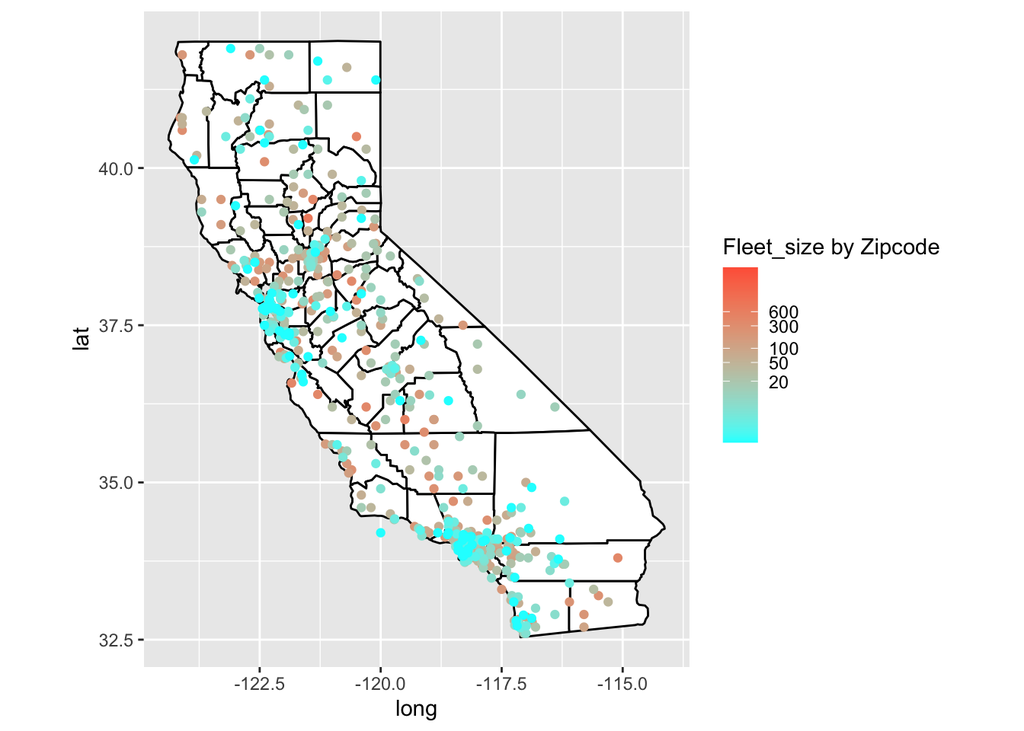

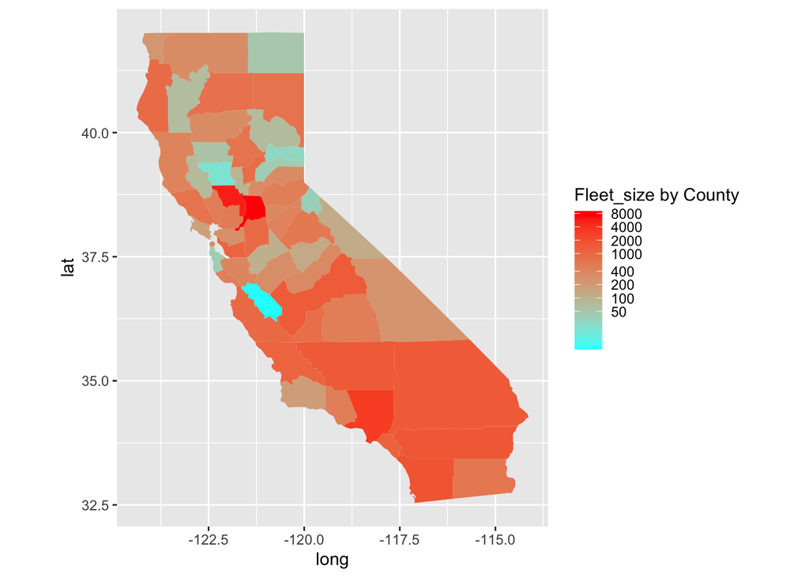